# Pima Indians Diabetes Analysis

```python
import numpy as np
import pandas as pd

import seaborn as sns
import matplotlib.pyplot as plt
%matplotlib inline
```

Observation: Import the necessary libraries:

1. Importing numpy because Less Memory, Fast and Convenient
2. Use Pandas for multidimensional structured data sets.
3. Use Seaborn to plot different visualization plots using various libraries for the 'diabetes' dataset.
4. Use Matplotlib.pyplot to plot different visualization plots using various libraries for the 'diabetes' dataset.

```python
pima = pd.read_csv("C:\\Users\\bilal\\Documents\\diabetes.csv")
```

Observation: Read the given dataset

```python
pima.tail(10)
```

|  | Pregnancies | Glucose | BloodPressure | SkinThickness | Insulin | BMI | DiabetesPedigreeFunction | Age | Outcome |
| --- | --- | --- | --- | --- | --- | --- | --- | --- | --- |
| 758 | 1 | 106 | 76 | 20 | 79 | 37.5 | 0.197 | 26 | 0 |
| 759 | 6 | 190 | 92 | 20 | 79 | 35.5 | 0.278 | 66 | 1 |
| 760 | 2 | 88 | 58 | 26 | 16 | 28.4 | 0.766 | 22 | 0 |
| 761 | 9 | 170 | 74 | 31 | 79 | 44.0 | 0.403 | 43 | 1 |
| 762 | 9 | 89 | 62 | 20 | 79 | 22.5 | 0.142 | 33 | 0 |
| 763 | 10 | 101 | 76 | 48 | 180 | 32.9 | 0.171 | 63 | 0 |
| 764 | 2 | 122 | 70 | 27 | 79 | 36.8 | 0.340 | 27 | 0 |
| 765 | 5 | 121 | 72 | 23 | 112 | 26.2 | 0.245 | 30 | 0 |
| 766 | 1 | 126 | 60 | 20 | 79 | 30.1 | 0.349 | 47 | 1 |
| 767 | 1 | 93 | 70 | 31 | 79 | 30.4 | 0.315 | 23 | 0 |

Observation: Show the last 10 records of the dataset and the amount of columns that are there

```python
pima.head(10)
```

|  | Pregnancies | Glucose | BloodPressure | SkinThickness | Insulin | BMI | DiabetesPedigreeFunction | Age | Outcome |
| --- | --- | --- | --- | --- | --- | --- | --- | --- | --- |
| 0 | 6 | 148 | 72 | 35 | 79 | 33.600000 | 0.627 | 50 | 1 |
| 1 | 1 | 85 | 66 | 29 | 79 | 26.600000 | 0.351 | 31 | 0 |
| 2 | 8 | 183 | 64 | 20 | 79 | 23.300000 | 0.672 | 32 | 1 |
| 3 | 1 | 89 | 66 | 23 | 94 | 28.100000 | 0.167 | 21 | 0 |
| 4 | 0 | 137 | 40 | 35 | 168 | 43.100000 | 2.288 | 33 | 1 |
| 5 | 5 | 116 | 74 | 20 | 79 | 25.600000 | 0.201 | 30 | 0 |
| 6 | 3 | 78 | 50 | 32 | 88 | 31.000000 | 0.248 | 26 | 1 |
| 7 | 10 | 115 | 69 | 20 | 79 | 35.300000 | 0.134 | 29 | 0 |
| 8 | 2 | 197 | 70 | 45 | 543 | 30.500000 | 0.158 | 53 | 1 |
| 9 | 8 | 125 | 96 | 20 | 79 | 31.992578 | 0.232 | 54 | 1 |

Observation: Show the first 10 records of the dataset

```python
pima.shape
```

```
(768, 9)
```

Observation: Dimension of the pima Dataframe

```python
pima.size
```

```
6912
```

Observation: size of the pima dataframe

```python
pima.info()
```

```
<class 'pandas.core.frame.DataFrame'>
RangeIndex: 768 entries, 0 to 767
Data columns (total 9 columns):
 #   Column                    Non-Null Count  Dtype
---  ------                    --------------  -----
 0   Pregnancies               768 non-null    int64
 1   Glucose                   768 non-null    int64
 2   BloodPressure             768 non-null    int64
 3   SkinThickness             768 non-null    int64
 4   Insulin                   768 non-null    int64
 5   BMI                       768 non-null    float64
 6   DiabetesPedigreeFunction  768 non-null    float64
 7   Age                       768 non-null    int64
 8   Outcome                   768 non-null    int64
dtypes: float64(2), int64(7)
memory usage: 54.1 KB
```

Observation: the data types of all the variables in the data set

```python
def missing_check(pima):
    total = pima.isnull().sum().sort_values(ascending=False)
    percent = (pima.isnull().sum()/pima.isnull().count()).sort_values(ascending=False)
    missing_pima = pd.concat([total, percent], axis=1, keys=['Total', 'Percent'])
    return missing_pima
missing_check(pima)
```

|  | Total | Percent |
| --- | --- | --- |
| Pregnancies | 0 | 0.0 |
| Glucose | 0 | 0.0 |
| BloodPressure | 0 | 0.0 |
| SkinThickness | 0 | 0.0 |
| Insulin | 0 | 0.0 |
| BMI | 0 | 0.0 |
| DiabetesPedigreeFunction | 0 | 0.0 |
| Age | 0 | 0.0 |
| Outcome | 0 | 0.0 |

Observation: Finding the missing values in the dataset

```python
pima.iloc[:,0:8].describe()
```

|  | Pregnancies | Glucose | BloodPressure | SkinThickness | Insulin | BMI | DiabetesPedigreeFunction | Age |
| --- | --- | --- | --- | --- | --- | --- | --- | --- |
| count | 768.000000 | 768.000000 | 768.000000 | 768.000000 | 768.000000 | 768.000000 | 768.000000 | 768.000000 |
| mean | 3.845052 | 121.675781 | 72.250000 | 26.447917 | 118.270833 | 32.450805 | 0.471876 | 33.240885 |
| std | 3.369578 | 30.436252 | 12.117203 | 9.733872 | 93.243829 | 6.875374 | 0.331329 | 11.760232 |
| min | 0.000000 | 44.000000 | 24.000000 | 7.000000 | 14.000000 | 18.200000 | 0.078000 | 21.000000 |
| 25% | 1.000000 | 99.750000 | 64.000000 | 20.000000 | 79.000000 | 27.500000 | 0.243750 | 24.000000 |
| 50% | 3.000000 | 117.000000 | 72.000000 | 23.000000 | 79.000000 | 32.000000 | 0.372500 | 29.000000 |
| 75% | 6.000000 | 140.250000 | 80.000000 | 32.000000 | 127.250000 | 36.600000 | 0.626250 | 41.000000 |
| max | 17.000000 | 199.000000 | 122.000000 | 99.000000 | 846.000000 | 67.100000 | 2.420000 | 81.000000 |

Observation: In the Pregnancies column, the count is 768, the mean is 3.85, the standard deviation is 3.37, the minimum is 0, the 1st Quartile is 1, the 50% Quartile is 3, the 3rd Quartile is 6 and the maximum is 17

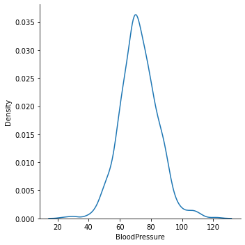

```python
sns.displot(pima['BloodPressure'], kind='kde')
plt.show()
```

Observation: Plotting the distribution plot for the variable 'BloodPressure'. At 70 Blood Pressure it reached its highest density at 0.035.

```python
pima[pima['Glucose']==pima['Glucose'].max()]['BMI']
```

```
661    42.9
Name: BMI, dtype: float64
```

Observation: The 'BMI' of the person having the highest 'Glucose

```python
m1 = pima['BMI'].mean()
print(m1)
m2 = pima['BMI'].median()
print(m2)
m3 = pima['BMI'].mode()[0]
print(m3)
```

```
32.450805155364556
32.0
32.0
```

Observation: The mean is 32.45, the median is 32.0, the mode is 32.0. The three measures of central tendency (mean, median, and mode) do not have to be equal. It depends on the distribution of the data.

```python
pima[pima['Glucose']>pima['Glucose'].mean()].shape[0]
```

```
343
```

Observation: The amount of women's 'Glucose' levels are above the mean level of 'Glucose'

```python
pima[(pima['BloodPressure']==pima['BloodPressure'].median()) & (pima['BMI']<pima['BMI'].median())]
```

|  | Pregnancies | Glucose | BloodPressure | SkinThickness | Insulin | BMI | DiabetesPedigreeFunction | Age | Outcome |
| --- | --- | --- | --- | --- | --- | --- | --- | --- | --- |
| 14 | 5 | 166 | 72 | 19 | 175 | 25.8 | 0.587 | 51 | 1 |
| 93 | 4 | 134 | 72 | 20 | 79 | 23.8 | 0.277 | 60 | 1 |
| 103 | 1 | 81 | 72 | 18 | 40 | 26.6 | 0.283 | 24 | 0 |
| 205 | 5 | 111 | 72 | 28 | 79 | 23.9 | 0.407 | 27 | 0 |
| 299 | 8 | 112 | 72 | 20 | 79 | 23.6 | 0.840 | 58 | 0 |
| 325 | 1 | 157 | 72 | 21 | 168 | 25.6 | 0.123 | 24 | 0 |
| 330 | 8 | 118 | 72 | 19 | 79 | 23.1 | 1.476 | 46 | 0 |
| 366 | 6 | 124 | 72 | 20 | 79 | 27.6 | 0.368 | 29 | 1 |
| 380 | 1 | 107 | 72 | 30 | 82 | 30.8 | 0.821 | 24 | 0 |
| 393 | 4 | 116 | 72 | 12 | 87 | 22.1 | 0.463 | 37 | 0 |
| 406 | 4 | 115 | 72 | 20 | 79 | 28.9 | 0.376 | 46 | 1 |
| 446 | 1 | 100 | 72 | 12 | 70 | 25.3 | 0.658 | 28 | 0 |
| 460 | 9 | 120 | 72 | 22 | 56 | 20.8 | 0.733 | 48 | 0 |
| 488 | 4 | 99 | 72 | 17 | 79 | 25.6 | 0.294 | 28 | 0 |
| 497 | 2 | 81 | 72 | 15 | 76 | 30.1 | 0.547 | 25 | 0 |
| 510 | 12 | 84 | 72 | 31 | 79 | 29.7 | 0.297 | 46 | 1 |
| 568 | 4 | 154 | 72 | 29 | 126 | 31.3 | 0.338 | 37 | 0 |
| 615 | 3 | 106 | 72 | 20 | 79 | 25.8 | 0.207 | 27 | 0 |
| 635 | 13 | 104 | 72 | 20 | 79 | 31.2 | 0.465 | 38 | 1 |
| 644 | 3 | 103 | 72 | 30 | 152 | 27.6 | 0.730 | 27 | 0 |
| 717 | 10 | 94 | 72 | 18 | 79 | 23.1 | 0.595 | 56 | 0 |
| 765 | 5 | 121 | 72 | 23 | 112 | 26.2 | 0.245 | 30 | 0 |

Observation: The amount of women who have their 'BloodPressure' equal to the median of 'BloodPressure' and their 'BMI' less than the median of 'BMI'

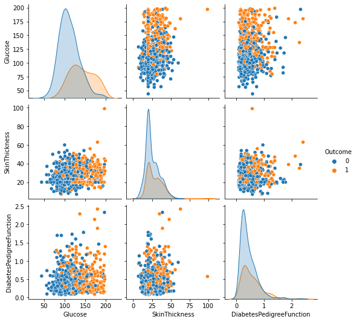

```python
sns.pairplot(data=pima,vars=['Glucose', 'SkinThickness', 'DiabetesPedigreeFunction'], hue='Outcome')
plt.show()
```

Observation: 1. There is a positive correlation between Glucose and Skin Thickness for people who have diabetes.

1. There is a positive correlation between Glucose and Diabetes Pedigree Function for people who have diabetes.
2. There is a positive correlation between Skin Thickness and Diabetes Pedigree Function for people who have diabetes.

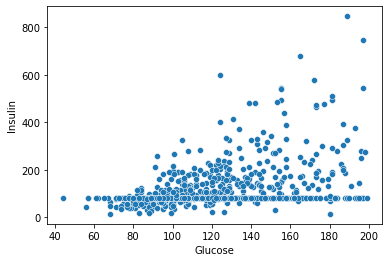

```python
sns.scatterplot(x='Glucose',y='Insulin',data=pima)
plt.show()
```

Observation: There is a positive correlation between the two variables, the dots will tend to fall along an upward diagonal line

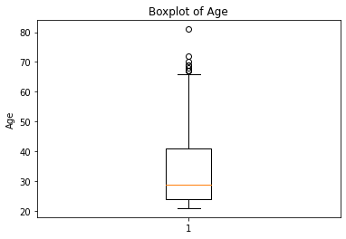

```python
plt.boxplot(pima['Age'])

plt.title('Boxplot of Age')
plt.ylabel('Age')
plt.show()
```

Observation: There are several outliers after the age of 65

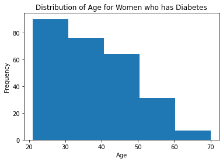

```python
plt.hist(pima[pima['Outcome']==1]['Age'], bins = 5)
plt.title('Distribution of Age for Women who has Diabetes')
plt.xlabel('Age')
plt.ylabel('Frequency')
plt.show()
```

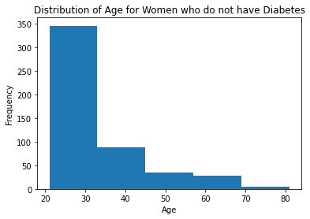

```python
plt.hist(pima[pima['Outcome']==0]['Age'], bins = 5)
plt.title('Distribution of Age for Women who do not have Diabetes')
plt.xlabel('Age')
plt.ylabel('Frequency')
plt.show()
```

```python
Q1 = pima.quantile(0.25)
Q3 = pima.quantile(0.75)
IQR = Q3 - Q1
print(IQR)
```

```
Pregnancies                  5.0000
Glucose                     40.5000
BloodPressure               16.0000
SkinThickness               12.0000
Insulin                     48.2500
BMI                          9.1000
DiabetesPedigreeFunction     0.3825
Age                         17.0000
Outcome                      1.0000
dtype: float64
```

Observation: A boxplot visualizes the same information as the IQR, which is the distribution of the dataset by displaying the median, quartiles, and any outliers. It is used to identify and exclude outliers, as any data point that falls more than the IQR beyond the first and third quartiles is considered an outlier.

```python
corr_matrix = pima.iloc[:,0:8].corr()

corr_matrix
```

|  | Pregnancies | Glucose | BloodPressure | SkinThickness | Insulin | BMI | DiabetesPedigreeFunction | Age |
| --- | --- | --- | --- | --- | --- | --- | --- | --- |
| Pregnancies | 1.000000 | 0.128022 | 0.208987 | 0.009393 | -0.018780 | 0.021546 | -0.033523 | 0.544341 |
| Glucose | 0.128022 | 1.000000 | 0.219765 | 0.158060 | 0.396137 | 0.231464 | 0.137158 | 0.266673 |
| BloodPressure | 0.208987 | 0.219765 | 1.000000 | 0.130403 | 0.010492 | 0.281222 | 0.000471 | 0.326791 |
| SkinThickness | 0.009393 | 0.158060 | 0.130403 | 1.000000 | 0.245410 | 0.532552 | 0.157196 | 0.020582 |
| Insulin | -0.018780 | 0.396137 | 0.010492 | 0.245410 | 1.000000 | 0.189919 | 0.158243 | 0.037676 |
| BMI | 0.021546 | 0.231464 | 0.281222 | 0.532552 | 0.189919 | 1.000000 | 0.153508 | 0.025748 |
| DiabetesPedigreeFunction | -0.033523 | 0.137158 | 0.000471 | 0.157196 | 0.158243 | 0.153508 | 1.000000 | 0.033561 |
| Age | 0.544341 | 0.266673 | 0.326791 | 0.020582 | 0.037676 | 0.025748 | 0.033561 | 1.000000 |

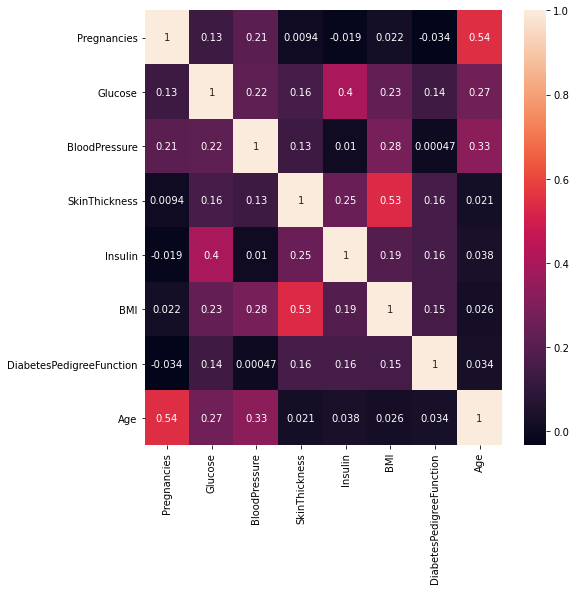

```python
plt.figure(figsize=(8,8))
sns.heatmap(corr_matrix, annot = True)
plt.show()
```

Observation: This will create a correlation matrix that shows the correlation coefficients between all pairs of variables in the dataset. The correlation coefficient ranges from -1 to 1, where -1 indicates a strong negative correlation, 0 indicates no correlation, and 1 indicates a strong positive correlation. It creates a heatmap using the seaborn library, where each cell in the matrix is color-coded to represent the strength of the correlation between the two variables. The heatmap is used to quickly identify strong correlations and patterns in the data.